# Code Description

Samuel C. de Assis

6/13/2021

## Data Input and Filtration

Data acquisition from reports, the names have been replaced by identification number. The result sample size was 958 reports after filtration by age. (limit age = 10 ; mes/meses = month/months)

```r
data0 <-
  read.csv("datacovid_1000_oficial.csv",
           stringsAsFactors = F,
           sep = ",")
data0 <- data0[!grepl("mes", data0$Idade),]
data0 <- data0[!grepl("meses", data0$Idade),]
data0$Idade <- as.numeric(as.character(data0$Idade))

data <- filter(data0, Idade > 10)
paged_table(data)
```

| Data | Nome | Idade | Sexo | Raca | Desfecho | Comorb | Dias_sint | Assinto | Febre | Epigastralgia | Calafrios | vomito | diarreia | artralgia | anosmia | ageusia | odino | cefaleia | adinamia | tosse | hemop | coriza | congest_nasal | dispneia | mialgia | prostra | astenia | inapet | fadiga | … |
| --- | --- | --- | --- | --- | --- | --- | --- | --- | --- | --- | --- | --- | --- | --- | --- | --- | --- | --- | --- | --- | --- | --- | --- | --- | --- | --- | --- | --- | --- | --- |
| NA | 1 | 35 | M | Branca | Domicílio após coleta exame |  |  | 9 | 1 | 9 | 2 | 9 | 2 | 2 | 9 | 9 | 1 | 2 | NA | 2 | NA | 2 | 2 | 1 | 2 | 9 | 9 | 9 | 1 | … |
| NA | 2 | 52 | M | Parda | UTI COVID | Hipertensão, Diabetes, Doença Renal | 4 | 2 | 1 | 9 | 2 | 2 | 2 | 2 | 2 | 2 | 2 | 2 | NA | 1 | NA | 2 | 2 | 1 | 2 | 1 | 2 | 1 | 2 | … |
| NA | 3 | 53 | M | Parda | Unidade de Internação COVID (Enfermaria, UCE, UTDI) | Diabetes, Doença cardiovascular | 7 | 2 | 1 | 9 | 2 | 2 | 2 | 2 | 2 | 2 | 2 | 1 | NA | 1 | NA | 1 | 2 | 1 | 1 | 1 | 1 | 9 | 2 | … |
| NA | 4 | 55 | M | Parda | UTI COVID | Ignorado | 9 | 9 | 1 | 9 | 9 | 2 | 2 | 2 | 9 | 9 | 2 | 2 | NA | 1 | NA | 2 | 2 | 1 | 2 | 2 | 2 | 2 | 2 | … |
| NA | 5 | 48 | M | Parda | Unidade de Internação COVID (Enfermaria, UCE, UTDI) | Hipertensão | 5 | 9 | 2 | 9 | 9 | 2 | 1 | 2 | 9 | 9 | 2 | 2 | NA | 1 | NA | 2 | 2 | 1 | 1 | 9 | 9 | 9 | 9 | … |
| NA | 6 | 45 | M | Parda | PA/PS Respiratório | Hipertensão | 4 | 9 | 2 | 9 | 9 | 2 | 1 | 2 | 9 | 9 | 2 | 1 | NA | 1 | NA | 2 | 2 | 2 | 1 | 9 | 9 | 9 | 9 | … |
| NA | 7 | 53 | F | Branca | Domicílio após coleta exame | Hipertensão, Diabetes | 1 | 2 | 1 | 9 | 2 | 2 | 2 | 2 | 9 | 9 | 1 | 1 | 1 | 1 | 9 | 1 | 2 | 2 | 1 | 9 | 9 | 9 | 9 | … |
| NA | 8 | 42 | F | Ignorado | Domicílio após coleta exame | Ignorado | 3 | 2 | 2 | 9 | 2 | 2 | 2 | 2 | 9 | 9 | 1 | 1 | 2 | 2 | 9 | 2 | 2 | 1 | 2 | 9 | 9 | 9 | 9 | … |
| NA | 9 | 20 | F | Branca | Domicílio após coleta exame | Ignorado | 3 | 2 | 2 | 9 | 2 | 2 | 2 | 2 | 1 | 9 | 1 | 1 | 2 | 1 | 9 | 1 | 2 | 2 | 2 | 9 | 9 | 9 | 9 | … |
| NA | 10 | 42 | M | Parda | UTI COVID | Diabetes | 7 | 2 | 1 | 9 | 2 | 2 | 2 | 2 | 9 | 9 | 2 | 2 | 1 | 1 | 1 | 2 | 2 | 2 | 2 | 2 | 1 | 1 | 2 | … |

[output cut: 948 more lines]

### Setting Comorbidities Data

```r
#Setting comorbidities data

comorbidades <- data %>%
  mutate(diabetes = case_when(
    str_detect(Comorb, "Diabetes") == TRUE ~ TRUE,
    str_detect(Comorb, "Diabetes") == FALSE ~ FALSE
  )) %>%
  mutate(hipertension = case_when(
    str_detect(Comorb, "HipertensÃ£o") == TRUE ~ TRUE,
    str_detect(Comorb, "HipertensÃ£o") == FALSE ~ FALSE
  )) %>%
  mutate(d_cardio = case_when(
    str_detect(Comorb, "DoenÃ§a cardiovascular") == TRUE ~ TRUE,
    str_detect(Comorb, "DoenÃ§a cardiovascular") == FALSE ~ FALSE
  )) %>%
  mutate(renal = case_when(
    str_detect(Comorb, "DoenÃ§a Renal") == TRUE ~ TRUE,
    str_detect(Comorb, "DoenÃ§a Renal") == FALSE ~ FALSE
  )) %>%
  mutate(pulmonar = case_when(
    str_detect(Comorb, "DoenÃ§a Pulmonar") == TRUE ~ TRUE,
    str_detect(Comorb, "DoenÃ§a Pulmonar") == FALSE ~ FALSE
  )) %>%
  mutate(neopla = case_when(
    str_detect(Comorb, "Neoplasia") == TRUE ~ TRUE,
    str_detect(Comorb, "Neoplasia") == FALSE ~ FALSE
  )) %>%
  mutate(immunodef = case_when(
    str_detect(Comorb, "ImunodeficiÃªncia") == TRUE ~ TRUE,
    str_detect(Comorb, "ImunodeficiÃªncia") == FALSE ~ FALSE
  )) %>%
  mutate(hiv = case_when(
    str_detect(Comorb, "InfecÃ§Ã£o HIV") == TRUE ~ TRUE,
    str_detect(Comorb, "InfecÃ§Ã£o HIV") == FALSE ~ FALSE
  )) %>%
  mutate(neuro = case_when(
    str_detect(Comorb, "DoenÃ§a NeurolÃ³gica") == TRUE ~ TRUE,
    str_detect(Comorb, "DoenÃ§a NeurolÃ³gica") == FALSE ~ FALSE
  )) %>%
  mutate(down = case_when(
    str_detect(Comorb, "SÃndrome de Down") == TRUE ~ TRUE,
    str_detect(Comorb, "SÃndrome de Down") == FALSE ~ FALSE
  )) %>%
  mutate(obesity = case_when(
    str_detect(Comorb, "Obesidade") == TRUE ~ TRUE,
    str_detect(Comorb, "Obesidade") == FALSE ~ FALSE
  )) %>%
  mutate(others = case_when(
    str_detect(Comorb, "Outras") == TRUE ~ TRUE,
    str_detect(Comorb, "Outras") == FALSE ~ FALSE
  )) %>%
  mutate(none_comor = case_when(
    str_detect(Comorb, "Sem morbidades") == TRUE ~ TRUE,
    str_detect(Comorb, "Sem morbidades") == FALSE ~ FALSE
  )) %>%
  mutate(comor_9 = case_when(
    str_detect(Comorb, "Ignorado") == TRUE ~ TRUE,
    str_detect(Comorb, "Ignorado") == FALSE ~ FALSE
  ))
```

## Figure 1

Violin graph describing the density age bin of patients admitted to different hospital units. The values could be check in **Values tab**.

### Plotting

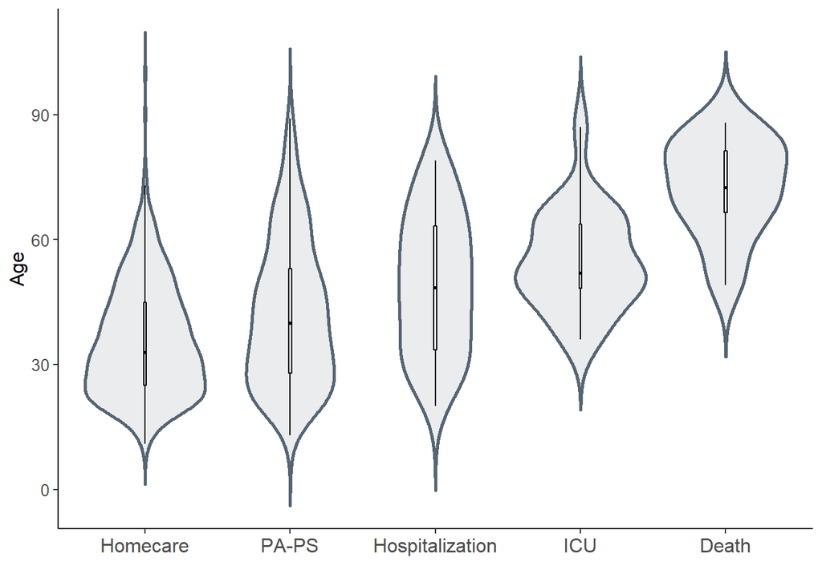

```r
#########################################Figure 1#########################################

#Setting Data
df_age_outcome <- data %>%
  mutate(
    desfec = case_when(
      Desfecho == "DomicÃlio apÃ³s coleta exame" ~ "Homecare",
      Desfecho == "UTI COVID" ~ "ICU",
      Desfecho == "Unidade de InternaÃ§Ã£o COVID (Enfermaria, UCE, UTDI)" ~ "Hospitalization",
      Desfecho == "PA/PS  RespiratÃ³rio" ~ "PA-PS",
      Desfecho == "Ã“bito" ~ "Death"
    )
  )

#Sorting by levels
df_age_outcome$desfec <-
  factor(df_age_outcome$desfec,
         levels = c("Homecare", "PA-PS", "Hospitalization", "ICU", "Death"))

#Plotting
plot1 <-
  ggplot(df_age_outcome, aes(x = desfec, y = Idade, fill = desfec)) +
  geom_violin(
    trim = FALSE,
    size = 1,
    fill = "#EAECEE",
    colour = "#566573"
  ) +
  geom_boxplot(
    width = 0.02,
    outlier.shape = NA,
    fill = "#EAECEE",
    color = "black"
  ) +
  labs(x = " ", y = "Age") +
  theme(
    panel.grid.major = element_blank(),
    panel.grid.minor = element_blank(),
    panel.background = element_blank(),
    axis.line = element_line(colour = "black"),
    legend.title = element_blank(),
    axis.text.x = element_text(size = 0.6 * 20),
    axis.title.y = element_text(size = 0.6 * 20),
    axis.text.y = element_text(size = 0.6 * 17)
  )

plot1
```

### Values

```r
median_age <- df_age_outcome %>%
  group_by(desfec)%>%
  summarise(Idade_Media=mean(Idade), Idade_Max=max(Idade), Idade_Min=min(Idade), Idade_Mediana=median(Idade), Std=sd(Idade), IQR= IQR(Idade))%>%
  ungroup()
paged_table(median_age)
```

| desfec | Idade_Media | Idade_Max | Idade_Min | Idade_Mediana | Std | IQR |
| --- | --- | --- | --- | --- | --- | --- |
| Homecare | 35.70899 | 100 | 11 | 33.0 | 13.40387 | 20.00 |
| PA-PS | 42.08485 | 89 | 13 | 40.0 | 17.29740 | 25.00 |
| Hospitalization | 49.40741 | 79 | 20 | 48.5 | 16.55582 | 29.75 |
| ICU | 54.95455 | 87 | 36 | 52.0 | 12.00586 | 15.50 |
| Death | 72.50000 | 88 | 49 | 72.5 | 11.62182 | 14.75 |

## Figure 2

In-Hospital stratified by (A) sex, (B) Hospital Units admission, (C) Number of comorbidities and (D) self-reported race. The values could be check in *Table 1*

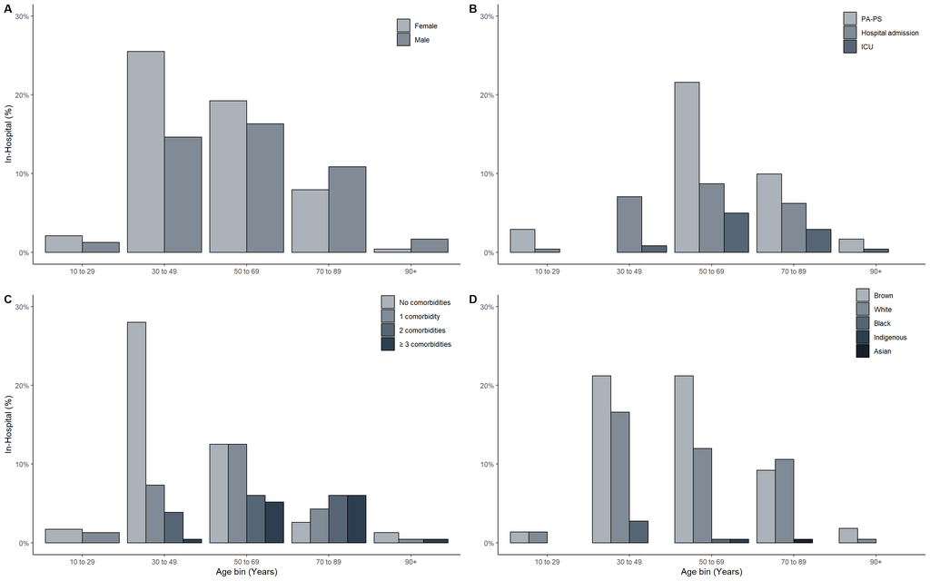

```r
#Graph colors
colors <- c("#ABB2B9",
             "#808B96",
             "#566573",
             "#2C3E50",
             "#17202A")

#Translation

df_geral <- comorbidades %>%
  mutate(sum = rowSums(.[37:48])) %>%
  mutate(cat_comor = cut(
    sum,
    breaks = c(seq(-1, 2, 1), 10),
    labels = c("No comorbidities", "1 comorbidity", "2 comorbidities", "\u2265 3 comorbidities"),
    include.lowest = TRUE
  )) %>%
  mutate(
    desfec = case_when(
      Desfecho == "DomicÃlio apÃ³s coleta exame" ~ "Homecare",
      Desfecho == "UTI COVID" ~ "Hospital admission",
      Desfecho == "Unidade de InternaÃ§Ã£o COVID (Enfermaria, UCE, UTDI)" ~ "Hospital admission",
      Desfecho == "PA/PS  RespiratÃ³rio" ~ "Hospital admission",
      Desfecho == "Ã“bito" ~ "Death"
    )
  ) %>%
  mutate(
    rac = case_when(
      Raca == "Ã\u008dndio" ~ "Indigenous",
      Raca == "Parda " ~ "Brown",
      Raca == "parda" ~ "Brown",
      Raca == "Parda" ~ "Brown",
      Raca == "Branca" ~ "White",
      Raca == "Indio" ~ "Indigenous",
      Raca == "Negra" ~ "Black",
      Raca == "" ~ "Missing",
      Raca == "Ignorado" ~ "Missing",
      Raca == "Amarela" ~ "Asian"
    )
  ) %>%
  mutate(sex = case_when(
    Sexo == "M" ~ "Male",
    Sexo == "F" ~ "Female",
    Sexo == "" ~ "Missing"
  )) %>%
  mutate(age_bin = cut(
    Idade,
    breaks = c(seq(0, 90, 20), 160),
    labels = c("10 to 29",
               "30 to 49",
               "50 to 69",
               "70 to 89",
               "90+"),
    include.lowest = TRUE
  )) %>%
  mutate(sex = case_when(
    Sexo == "M" ~ "Male",
    Sexo == "F" ~ "Female",
    Sexo == "" ~ "Missing"
  )) %>%
  mutate(
    desfec1 = case_when(
      Desfecho == "DomicÃlio apÃ³s coleta exame" ~ "Homecare",
      Desfecho == "UTI COVID" ~ "ICU",
      Desfecho == "Unidade de InternaÃ§Ã£o COVID (Enfermaria, UCE, UTDI)" ~ "Hospital admission",
      Desfecho == "PA/PS  RespiratÃ³rio" ~ "PA-PS",
      Desfecho == "Ã“bito" ~ "Death"
    )
  )

#A. Stratified by sex
plot2 <- df_geral %>%
  filter(sex != "Missing") %>%
  filter(desfec == "Hospital admission") %>%
  ggplot(., aes(x = age_bin, fill = sex)) +
  geom_bar(aes(y = after_stat(count / sum(count))),
           position = position_dodge(preserve = "single"),
           color = "black") +
  scale_y_continuous(
    labels = function(x)
      paste0(x * 100, "%"),
    limits = c(0, 0.3)
  ) +
  scale_fill_manual(
    values = c(
      colors[1],
      colors[2]
    ),
    name = ""
  ) +
  labs(x = " ",
       y = "In-Hospital (%)") +
  theme(
    panel.grid.major = element_blank(),
    panel.grid.minor = element_blank(),
    panel.background = element_blank(),
    axis.line = element_line(colour = "black"),
    legend.title = element_blank(),
    legend.position = c(0.9, 0.9)
  )


#B. Stratified by hospital units
df_geral$desfec1 <-
  factor(df_geral$desfec1, levels = c("PA-PS", "Hospital admission", "ICU"))

plot3 <- df_geral %>%
  filter(desfec1 != "Missing") %>%
  filter(desfec == "Hospital admission") %>%
  ggplot(., aes(x = age_bin, fill = desfec1)) +
  geom_bar(aes(y = after_stat(count / sum(count))),
           position = position_dodge(preserve = "single"),
           color = "black") +
  scale_y_continuous(
    labels = function(x)
      paste0(x * 100, "%"),
    limits = c(0, 0.3)
  ) +
  scale_fill_manual(
    values = c(
      colors[1],
      colors[2],
      colors[3],
      colors[4]
    ),
    name = ""
  ) +
  labs(x = " ",
       y = " ") +
  theme(
    panel.grid.major = element_blank(),
    panel.grid.minor = element_blank(),
    panel.background = element_blank(),
    axis.line = element_line(colour = "black"),
    legend.title = element_blank(),
    legend.position = c(0.9, 0.9)
  )

#C. Stratified by N. of comorbidities
plot4 <- df_geral %>%
  filter(comor_9 != TRUE) %>%
  filter(desfec == "Hospital admission") %>%
  ggplot(., aes(x = age_bin, fill = cat_comor)) +
  geom_bar(aes(y = after_stat(count / sum(count))),
           position = position_dodge(),
           color = "black") +
  scale_y_continuous(
    labels = function(x)
      paste0(x * 100, "%"),
    limits = c(0, 0.3)
  ) +
  scale_fill_manual(
    values = c(
      colors[1],
      colors[2],
      colors[3],
      colors[4],
      colors[5]
    ),
    name = ""
  ) +
  labs(x = "Age bin (Years)",
       y = "In-Hospital (%)") +
  theme(
    panel.grid.major = element_blank(),
    panel.grid.minor = element_blank(),
    panel.background = element_blank(),
    axis.line = element_line(colour = "black"),
    legend.title = element_blank(),
    legend.position = c(0.9, 0.9)
  )

#D. Stratified by self-reported race

df_geral$rac <-
  factor(df_geral$rac,
         levels = c("Brown", "White", "Black", "Indigenous", "Asian", "Missing"))
plot5 <- df_geral %>%
  filter(rac != "Missing") %>%
  filter(desfec == "Hospital admission") %>%
  ggplot(., aes(x = age_bin, fill = rac)) +
  geom_bar(aes(y = after_stat(count / sum(count))),
           position = position_dodge(preserve = "single"),
           color = "black") +
  scale_y_continuous(
    labels = function(x)
      paste0(x * 100, "%"),
    limits = c(0, 0.3)
  ) +
  scale_fill_manual(
    values = c(
      colors[1],
      colors[2],
      colors[3],
      colors[4],
      colors[5]
    ),
    name = ""
  ) +
  labs(x = "Age bin (Years)",
       y = " ") +
  theme(
    panel.grid.major = element_blank(),
    panel.grid.minor = element_blank(),
    panel.background = element_blank(),
    axis.line = element_line(colour = "black"),
    legend.title = element_blank(),
    legend.position = c(0.9, 0.9)
  )

#Combine and plot
combined_plot <-
  ggpubr::ggarrange(
    plot2,
    plot3,
    plot4,
    plot5,
    heights = c(2, 2),
    nrow = 2,
    ncol = 2,
    labels = c("A", "B", "C", "D"),
    font.label = list(size = 14, face = "bold", color ="black"),
    align = "hv"
  )
combined_plot
```

## Figure 3

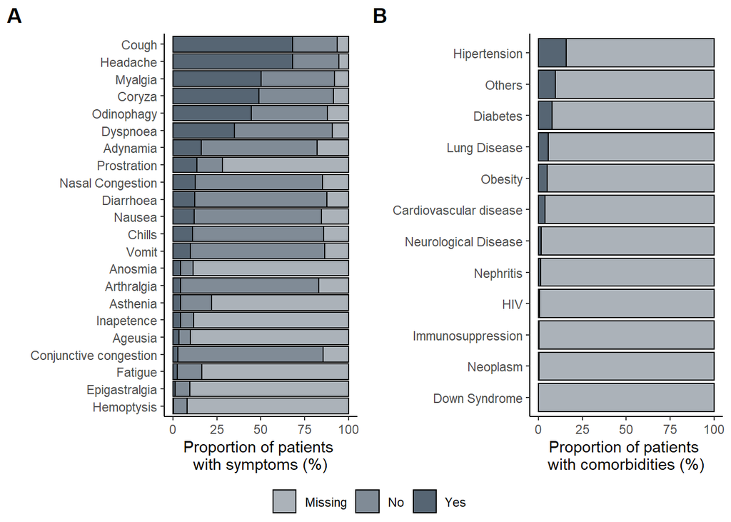

```r
#A. Proportion of symptoms reported
symp <- df_geral %>% select(
  Epigastralgia = Epigastralgia,
  Chills = Calafrios,
  Vomit = vomito,
  Diarrhoea = diarreia,
  Arthralgia = artralgia,
  Anosmia = anosmia,
  Ageusia = ageusia,
  Odinophagy = odino,
  Headache = cefaleia,
  Adynamia = adinamia,
  Cough = tosse,
  Hemoptysis = hemop,
  Coryza = coriza,
  "Nasal Congestion" = congest_nasal,
  Dyspnoea = dispneia,
  Myalgia = mialgia,
  Prostration = prostra,
  Asthenia = astenia,
  Inapetence = inapet,
  Fatigue = fadiga,
  Nausea = nausea,
  "Conjunctive congestion" = congest_conj)

symp <- map_df(symp, ~ ifelse(.x == 2, 0, ifelse(.x == 9, NA_integer_, .x)))

symp <- gather(symp, key = "Sintoma", value = "Valor") %>%
  group_by(Sintoma, Valor) %>%
  tally()

symp <- symp %>%
  ungroup() %>%
  mutate(Valor = case_when(
    is.na(Valor) ~ "Missing",
    Valor == 1 ~ "Yes",
    Valor == 0 ~ "No"
  ))

# Calculate the proportion of patients with each symptom
symp <- symp %>%
  group_by(Sintoma) %>%
  mutate(total = sum(n),
         prop = n / total)

# Order for the plot to be stacked in
order <- symp %>%
  ungroup() %>%
  filter(Valor == "Yes") %>%
  arrange(desc(prop)) %>%
  mutate(order = 1:nrow(.))

symp <- symp %>% left_join(order %>% select(Sintoma, order))
symp <- symp %>% mutate(Valor = factor(Valor, levels = c("Missing","No", "Yes")))
plot6 <- ggplot(symp) +
  geom_col(aes(x = prop*100, y = reorder(Sintoma, -order), fill = Valor), color = "black") +
  labs(x = "Proportion of patients
with symptoms (%)",
       y = "",
       fill = "") +
  scale_fill_manual(
    values = c(
      colors[1],
      colors[2],
      colors[3],
    name = ""
  ))+
  theme_classic()


#B. Proportion of comorbidities reported
plot7 <- df_geral %>% select(
  Diabetes = diabetes,
  Hipertension = hipertension,
  "Cardiovascular disease" = d_cardio,
  Nephritis = renal,
  "Lung Disease" = pulmonar,
  Neoplasm = neopla,
  Immunosuppression = immunodef,
  HIV = hiv,
  "Neurological Disease" = neuro,
  "Down Syndrome" = down,
  Obesity = obesity,
  Others = others)

plot7[1:12] <- map_df(plot7[1:12], ~ ifelse(.x == FALSE, 0, ifelse(.x == 9, NA_integer_, .x)))

# Long format
plot7 <- gather(plot7, key = "comorb", value = "Valor") %>%
  group_by(comorb, Valor) %>%
  tally()

plot7 <- plot7 %>%
  ungroup() %>%
  mutate(Valor = case_when(
    is.na(Valor) ~ "Missing",
    Valor == TRUE ~ "Yes",
    Valor == FALSE ~ "No"
  ))

# Calculate the proportion of patients with each comorbidity
plot7 <- plot7 %>%
  group_by(comorb) %>%
  mutate(total = sum(n),
         prop = n / total)

order <- plot7 %>%
  ungroup() %>%
  filter(Valor == "Yes") %>%
  arrange(desc(prop)) %>%
  mutate(order = 1:nrow(.))

plot7 <- plot7 %>%
  left_join(order %>% select(comorb, order))

plot7 <- plot7 %>% mutate(Valor = factor(Valor, levels = c("Missing","No", "Yes")))

plot7c <- ggplot(plot7) +
  geom_col(aes(x = prop*100, y = reorder(comorb, -order), fill = Valor), color = "black") +
  labs(x = "Proportion of patients
with comorbidities (%)",
       y = "",
       fill = "") +
  scale_fill_manual(
    values = c(
      colors[1],
      colors[3],
      name = ""
    )) +
  ggtitle("") +
  theme_classic()


combined_plot1 <-
  ggpubr::ggarrange(
    plot6,
    plot7c,
    nrow = 1,
    ncol = 2,
    align = "hv",
    common.legend = TRUE,
    legend = "bottom",
    labels = c("A", "B"),
    font.label = list(size = 14, face = "bold", color ="black")
  )
combined_plot1
```

## Table 1

```r
######################################TABLE1##############################################

#Data Input and Filtration
data_table <-
  read.csv("datacovid_1000_oficial.csv",
           stringsAsFactors = F,
           sep = ",")

data_table <- data_table[!grepl("mes", data_table$Idade),]
data_table <- data_table[!grepl("meses", data_table$Idade),]
data_table$Dias_sint <- as.numeric(as.character(data_table$Dias_sint))
data_table$Idade <- as.numeric(as.character(data_table$Idade))
data_tab <- filter(data_table, Idade > 10)

#Classification and Translation
df_data <- data_tab %>%
  mutate(age_bin = cut(
    Idade,
    breaks = c(seq(10, 90, 10), 150),
    labels = c(
      "10 to 19",
      "20 to 29",
      "30 to 39",
      "40 to 49",
      "50 to 59",
      "60 to 69",
      "70 to 79",
      "80 to 89",
      "90+"
    ),
    include.lowest = TRUE
  )) %>%
  mutate(
    desfec = case_when(
      Desfecho == "DomicÃlio apÃ³s coleta exame" ~ "No admission",
      Desfecho == "UTI COVID" ~ "Admission",
      Desfecho == "Unidade de InternaÃ§Ã£o COVID (Enfermaria, UCE, UTDI)" ~ "Admission",
      Desfecho == "PA/PS  RespiratÃ³rio" ~ "Admission",
      Desfecho == "Ã“bito" ~ "Death"
    )
  ) %>%
  mutate(sex = case_when(
    Sexo == "M" ~ "Male",
    Sexo == "F" ~ "Female",
    Sexo == "" ~ NA_character_)) %>%
  mutate(
    rac = case_when(
      Raca == "Ã\u008dndio" ~ "Indigenous",
      Raca == "Parda " ~ "Brown",
      Raca == "parda" ~ "Brown",
      Raca == "Parda" ~ "Brown",
      Raca == "Branca" ~ "White",
      Raca == "Indio" ~ "Indigenous",
      Raca == "Negra" ~ "Black",
      Raca == "" ~ NA_character_,
      Raca == "Ignorado" ~ NA_character_,
      Raca == "Amarela" ~ "Asian"
    )
  ) %>%
  mutate(diabetes = case_when(
    str_detect(Comorb, "Diabetes") == TRUE ~ TRUE,
    str_detect(Comorb, "Diabetes") == FALSE ~ FALSE
  )) %>%
  mutate(hipertensao = case_when(
    str_detect(Comorb, "HipertensÃ£o") == TRUE ~ TRUE,
    str_detect(Comorb, "HipertensÃ£o") == FALSE ~ FALSE
  )) %>%
  mutate(d_cardio = case_when(
    str_detect(Comorb, "DoenÃ§a cardiovascular") == TRUE ~ TRUE,
    str_detect(Comorb, "DoenÃ§a cardiovascular") == FALSE ~ FALSE
  )) %>%
  mutate(renal = case_when(
    str_detect(Comorb, "DoenÃ§a Renal") == TRUE ~ TRUE,
    str_detect(Comorb, "DoenÃ§a Renal") == FALSE ~ FALSE
  )) %>%
  mutate(pulmonar = case_when(
    str_detect(Comorb, "DoenÃ§a Pulmonar") == TRUE ~ TRUE,
    str_detect(Comorb, "DoenÃ§a Pulmonar") == FALSE ~ FALSE
  )) %>%
  mutate(neoplasia = case_when(
    str_detect(Comorb, "Neoplasia") == TRUE ~ TRUE,
    str_detect(Comorb, "Neoplasia") == FALSE ~ FALSE
  )) %>%
  mutate(imunodef = case_when(
    str_detect(Comorb, "ImunodeficiÃªncia") == TRUE ~ TRUE,
    str_detect(Comorb, "ImunodeficiÃªncia") == FALSE ~ FALSE
  )) %>%
  mutate(hiv = case_when(
    str_detect(Comorb, "InfecÃ§Ã£o HIV") == TRUE ~ TRUE,
    str_detect(Comorb, "InfecÃ§Ã£o HIV") == FALSE ~ FALSE
  )) %>%
  mutate(neuro = case_when(
    str_detect(Comorb, "DoenÃ§a NeurolÃ³gica") == TRUE ~ TRUE,
    str_detect(Comorb, "DoenÃ§a NeurolÃ³gica") == FALSE ~ FALSE
  )) %>%
  mutate(down = case_when(
    str_detect(Comorb, "SÃndrome de Down") == TRUE ~ TRUE,
    str_detect(Comorb, "SÃndrome de Down") == FALSE ~ FALSE
  )) %>%
  mutate(obesidade = case_when(
    str_detect(Comorb, "Obesidade") == TRUE ~ TRUE,
    str_detect(Comorb, "Obesidade") == FALSE ~ FALSE
  )) %>%
  mutate(outras = case_when(
    str_detect(Comorb, "Outras") == TRUE ~ TRUE,
    str_detect(Comorb, "Outras") == FALSE ~ FALSE
  )) %>%
  mutate(sem_comor = case_when(
    str_detect(Comorb, "Sem morbidades") == TRUE ~ TRUE,
    str_detect(Comorb, "Sem morbidades") == FALSE ~ FALSE
  )) %>%
  mutate(comor_9 = case_when(
    str_detect(Comorb, "Ignorado") == TRUE ~ TRUE,
    str_detect(Comorb, "Ignorado") == FALSE ~ FALSE
  )) %>%
  mutate(sum = rowSums(.[41:52])) %>%
  mutate(cat_comor = cut(
    sum,
    breaks = c(seq(-1, 2, 1), 10),
    labels = c("No comorbidities", "1 comorbidity", "2 comorbidities", "\u2265 3 comorbidities"),
    include.lowest = TRUE
  ))

#Missing values definied as NA values
df_data$cat_comor[df_data$comor_9 == TRUE] <- NA_character_

df_data[, c(10:35)] <- map2_df(df_data[, c(10:34)], names(df_data[, c(10:34)]), ~ case_when(
    .x == 1 ~ .y,
    .x == 2 ~ NA_character_,
    .x == 3 ~ "Ex",
    .x == 9 ~ NA_character_
  ))



df_data2 <- df_data %>%
  select("Symptoms Appearance" = Dias_sint,
         Sex = sex,
         Age = Idade,
         "Age bin" = age_bin,
         "Self-reported Race" = rac,
         Outcome = desfec,
         "Num. of Comorbidities" = cat_comor,
         Diabetes = diabetes,
         Hipertension = hipertensao,
         "Cardiovascular Disease" = d_cardio,
         Nephritis = renal,
         "Lung Disease" = pulmonar,
         "Neoplasm" = neoplasia,
         "Immunosupression" = imunodef,
         HIV = hiv,
         "Neurological Disease" = neuro,
         "Down Sydrome" = down,
         )

#Plotting table as .html file.

table1 = df_data2 %>%
  tbl_summary (by = Outcome,
               missing= "no",
               type = all_continuous() ~ "continuous2",
               statistic = list(all_categorical() ~ "{n} ({p}%)",
                                all_continuous() ~ c("{mean} ({sd})",
                                                     "{median} ({p25}-{p75})",
                                                     "{min}, {max}")
                                )) %>%
  add_overall() %>%
  bold_labels %>%
  add_n() %>%
  as_gt()# %>%
  #gt::gtsave(filename = "tabela.html")

table1
```

| **Characteristic** | **N** | **Overall**, N = 958<sup>1</sup> | **Admission**, N = 241 | **Death**, N = 16 | **No admission**, N = 701 |
| --- | --- | --- | --- | --- | --- |
| Symptoms Appearance | 884 |  |  |  |  |
| Mean (SD) |  | 4.30 (2.66) | 4.55 (2.90) | 8.50 (9.70) | 4.16 (2.34) |
| Median (25%-75%) |  | 4.00 (3.00-6.00) | 4.00 (3.00-6.00) | 4.50 (3.50-9.00) | 4.00 (3.00-6.00) |
| Range |  | 0.00, 30.00 | 0.00, 21.00 | 1.00, 30.00 | 0.00, 17.00 |
| Sex | 950 |  |  |  |  |
| Female |  | 535 (56%) | 132 (55%) | 9 (60%) | 394 (57%) |
| Male |  | 415 (44%) | 107 (45%) | 6 (40%) | 302 (43%) |
| Age | 958 |  |  |  |  |
| Mean (SD) |  | 39 (16) | 45 (17) | 72 (12) | 36 (13) |
| Median (25%-75%) |  | 36 (26-49) | 44 (31-57) | 72 (66-81) | 33 (25-45) |
| Range |  | 11, 100 | 13, 89 | 49, 88 | 11, 100 |
| Age bin | 958 |  |  |  |  |
| 10 to 19 |  | 80 (8.4%) | 8 (3.3%) | 0 (0%) | 72 (10%) |
| 20 to 29 |  | 262 (27%) | 49 (20%) | 0 (0%) | 213 (30%) |
| 30 to 39 |  | 232 (24%) | 48 (20%) | 0 (0%) | 184 (26%) |
| 40 to 49 |  | 175 (18%) | 49 (20%) | 1 (6.2%) | 125 (18%) |
| 50 to 59 |  | 111 (12%) | 36 (15%) | 1 (6.2%) | 74 (11%) |
| 60 to 69 |  | 63 (6.6%) | 33 (14%) | 4 (25%) | 26 (3.7%) |
| 70 to 79 |  | 22 (2.3%) | 13 (5.4%) | 4 (25%) | 5 (0.7%) |
| 80 to 89 |  | 12 (1.3%) | 5 (2.1%) | 6 (38%) | 1 (0.1%) |
| 90+ |  | 1 (0.1%) | 0 (0%) | 0 (0%) | 1 (0.1%) |
| Self-reported Race | 758 |  |  |  |  |
| Asian |  | 5 (0.7%) | 1 (0.5%) | 0 (0%) | 4 (0.8%) |
| Black |  | 19 (2.5%) | 7 (3.2%) | 0 (0%) | 12 (2.3%) |
| Brown |  | 428 (56%) | 119 (55%) | 12 (80%) | 297 (56%) |
| Indigenous |  | 2 (0.3%) | 1 (0.5%) | 0 (0%) | 1 (0.2%) |
| White |  | 304 (40%) | 89 (41%) | 3 (20%) | 212 (40%) |
| Num. of Comorbidities | 885 |  |  |  |  |
| No comorbidities |  | 575 (65%) | 107 (46%) | 1 (7.1%) | 467 (73%) |
| 1 comorbidity |  | 191 (22%) | 60 (26%) | 4 (29%) | 127 (20%) |
| 2 comorbidities |  | 71 (8.0%) | 37 (16%) | 3 (21%) | 31 (4.9%) |
| ≥ 3 comorbidities |  | 48 (5.4%) | 28 (12%) | 6 (43%) | 14 (2.2%) |
| Diabetes | 958 | 74 (7.7%) | 32 (13%) | 7 (44%) | 35 (5.0%) |
| Hipertension | 958 | 151 (16%) | 67 (28%) | 9 (56%) | 75 (11%) |
| Cardiovascular Disease | 958 | 35 (3.7%) | 17 (7.1%) | 5 (31%) | 13 (1.9%) |
| Nephritis | 958 | 12 (1.3%) | 9 (3.7%) | 1 (6.2%) | 2 (0.3%) |
| Lung Disease | 958 | 54 (5.6%) | 23 (9.5%) | 1 (6.2%) | 30 (4.3%) |
| Neoplasm | 958 | 3 (0.3%) | 3 (1.2%) | 0 (0%) | 0 (0%) |
| Immunosupression | 958 | 4 (0.4%) | 1 (0.4%) | 0 (0%) | 3 (0.4%) |
| HIV | 958 | 6 (0.6%) | 2 (0.8%) | 0 (0%) | 4 (0.6%) |
| Neurological Disease | 958 | 14 (1.5%) | 10 (4.1%) | 2 (12%) | 2 (0.3%) |
| Down Sydrome | 958 | 1 (0.1%) | 0 (0%) | 0 (0%) | 1 (0.1%) |

<sup>*1*</sup> c("Mean (SD)", "Median (25%-75%)", "Range"); n (%)

## References

Reference papers have been consulted to develop this code, thanks to your reproducibility approach.

[1] DE SOUZA, W. M. et al. Epidemiological and clinical characteristics of the COVID-19 epidemic in Brazil. Nature Human Behaviour, vol. 4, p. 856-865, 2020. DOI: https://doi.org/10.1038/s41562-020-0928-4

[2] RANZANI, O. et al. Characterisation of the first 250 000 hospital admissions for COVID-19 in Brazil: a retrospective analysis of nationwide. The Lancet Respiratory Medicine. Vol 9,p. 407-418, 2021. DOI: https://doi.org/10.1016/S2213-2600(20)30560-9